# Introducción Python para Análisis de Datos

## Introducción

Antes de pasar a los ejemplos de **[Machine Learning (ML)](https://en.wikipedia.org/wiki/Machine_learning) o Aprendizaje Automático**, consideramos adecuado hacer algunos comentarios y ejemplos de algunos de los paquetes que se usan para el Análisis de Datos en Python y claro, hacer algunos ejemplos del [lenguaje](https://www.python.org/).

Para el desarrollo del tutorial estan considerados varios de los paquetes más importantes para abordar algún proyecto de ML. A grandes rasgos un proyecto de ML tienen varias fases, de una manera muy global podrían considerarse las siguientes:

[figure not shown]

En la tercera etapa del diagrama anterior es donde se hace uso fuertemente ML, pero puede ocurrir que en algunas de las etapas previas se haga uso de algún algoritmo o técnica como herramienta auxiliar para el pre-procesamiento o la exploración. Esto depende mucho de la situación que presentan los datos.

En un proyecto en general se invierte un **80%** de tiempo en las dos primeras etapas y solo un **20%** en el resto; es decir, en la parte donde será más relevante ML solo representa un 20% del tiempo invertido y del esfuerzo del proyecto. Por lo cual es fundamental contar con un buen entorno para hacer pre-procesamiento y exploración de los datos.

En la práctica en un proyecto se busca seguir alguna metodología para el desarrollo, y se busca definir un plan de trabajo lo mejor posible. Hay varias metodologías para tratar de llevar algún proyecto de ML, un ejemplo es la propuesta de [IBM](https://www.ibm.com/us-en/) para proyectos de *"Ciencia de Datos" o "Minería de Datos"*:

[figure not shown]

El diagrama muestra las etapas que se busca ir realizando, todas son importantes. Pero las primeras 6 definen en gran medida lo que se pueda implementar de ML o no. Este proceso muestra cómo se desarrollan la mayoría de proyectos donde se busca hacer algún tipo de sistema que contenga algo de "Analítica". Y de nueva cuenta, el esfuerzo o tiempo invertido resulta ser mayor en las primeras 6 etapas.

Con esos dos ejemplos, tanto de las etapas generales como del proceso para un caso de negocio, resaltamos que contar con un buen conocimiento del procesamiento de los datos, de una buena exploración tanto de las características como sus relaciones estadísticas resulta fundamental. En muchas situaciones la información que se recibe inicialmente no cuenta con la "madurez" adecuada para poder ser "explotada" ni gráficamente ni analíticamente.

En la mayoría de las empresas se hace uso de algún repositorio para los datos, con el cual se hace una base de datos. Las consultas a dicha base de datos se hacen mediante SQL, y pese a que se puede hacer gran parte de exploración de la información en dicho lenguaje, resulta menos flexible que la realizable con entornos como el de Python para hacer Análisis de Datos.

*Nota:* Otro factor importante es el volumen de información que se analiza, para ciertos casos puede resultar importante analizar o construir la muestra de datos necesaria para hacer algún modelo en una base de datos y luego pasar esa información a un entorno más adecuado.

## Lenguaje de Programación Python

Python es un lenguaje de Programación Interpretado y multiparadigma ya que se puede hacer programación orientada a objetos, programación imperativa y soporta alguna capacidades de programación funcional. Unas recomendaciones para aprender a programar en este lenguaje son:

- https://docs.python.org/3/
- [Learn Python the Hard Way](https://learnpythonthehardway.org/)
- [Dive Into Python](http://www.diveintopython3.net/)

Los dos libros cuentan con una versión libre en su sitio web y en el sitio web de Python se tienen tutoriales para iniciar o cuenta con la documentación necesaria para profundizar en el uso del lenguaje.

Para el tutorial basta con tener algunas nociones de programación imperativa, un aspecto importante y necesario es tener conocimientos mínimos sobre estructuras de datos básicas: *listas, conjuntos, tuplas, diccionarios.*

- Un material de apoyo sobre estos objtos se puede encontar [aquí.](https://github.com/dlegor/cs228-material_en_esp)

### Ejemplos en Python

Como ejemplo se resuelve el problema de las **Torres de Hanoi**, para ejecutar el código solo basta elegir el botón *run cell* o combinar las teclas **Ctrl+Enter** al colocarse sobre la celda donde se encuentra el código.

```python
#Código de Brad Miller and David Ranum


#Definicion de la Funcion de Movimientos
def moveTower(height,fromPole, toPole, withPole):
    if height >= 1:
        moveTower(height-1,fromPole,withPole,toPole)
        moveDisk(fromPole,toPole)
        moveTower(height-1,withPole,toPole,fromPole)

#Presentación de los Movimientos realizados
def moveDisk(fp,tp):
    print("Moviendo el disco desde la torre",fp,"a la torre",tp)

#Ejecución de programa
moveTower(3,"A","B","C")
```

```
Moviendo el disco desde la torre A a la torre B
Moviendo el disco desde la torre A a la torre C
Moviendo el disco desde la torre B a la torre C
Moviendo el disco desde la torre A a la torre B
Moviendo el disco desde la torre C a la torre A
Moviendo el disco desde la torre C a la torre B
Moviendo el disco desde la torre A a la torre B
```

El ejemplo anterios muestra como definir una función y hacer uso de la recursividad, con un poco de esfuezo se puede ir leyendo las indicaciones y resulta muy fácil de leer un código en python.

El siguiente ejemplo muestra como se obtiene un mismo resultado de diferentes maneras, la intención es mostrar la diversidad de formas y no tanto ver cuál es la mejor manera de construir una lista.

```python
# Se genera una rango de números
Rango=range(0,10)

#Se define la lista vacía
L=[]

#Ciclo sobre los elementos de Rango
for i in Rango:
    L.append(i*i)#Se van agregando los elementos de Rango

#Se presenta la lista
print(L)
```

```
[0, 1, 4, 9, 16, 25, 36, 49, 64, 81]
```

```python
#Construcción de una lista con los elementos de Rango

#Listas por compresión
[i*i for i in Rango]
```

```
[0, 1, 4, 9, 16, 25, 36, 49, 64, 81]
```

```python
#Se contruye una lista con todos los números, pero se hace uso de una función lambda, útiles en
# programación funcional

list(map(lambda x: x*x,Rango))
```

```
[0, 1, 4, 9, 16, 25, 36, 49, 64, 81]
```

Los 3 ejemplo muestran aspectos diferentes de la programación en Python. En el primero ejemplo se hace uso del método *append* de las listas. Lo que hace es agregar al final cada nuevo elemento.

Para el segundo ejemplo se hace uso de una *lista por compresión*, es un modo de crear listas desde otra lista (también se puede hacer desde los elementos de un diccionario). Este tipo de construcción es más similar a la notación de teoría de conjuntos. Si se observa la notación de la lista y la definición del siguiente conjunto podrás observar la similaridad.

\begin{align} Conjunto=\{x*x \mid \text{ Para todo x en Rango}\} \end{align}

En el último ejemplo, se usan las funciones *list, map y lambda*. La función *list()* es como su nombre lo indica para contruir una lista. La función *map()* es un mapeo de la función lambda sobre los elementos que están en Rango. Esta es una función estandar en programación funcional y funciona igual que el concepto de función en un sentido matemático.

La función *lamnda* es un tipo de función estandar en la programación funcional, se les llama *funciones anónimas o expresiones lambda*. Ayudan a definir funciones, qué son aplicadas al momento, pero no reusables. Ejemplo el último codigo se podía programar contando con la definición normal de una función y aplicarla con *map()*.

```
def cuadrado(x): return x*x

list(map(cuadrado,Rango))
```

El resultado es el mismo que se obtiene con el uso de la función lambda. Para ver algunos ejemplos de programación funcional básica con Python se pueden consultar en la siguientes referencias:

- [El blog de Mary Rose](https://maryrosecook.com/blog/post/a-practical-introduction-to-functional-programming) para ejemplo sencillos.
- El texto ["Funtional Programming in Python"](http://www.oreilly.com/programming/free/functional-programming-python.csp) de [David Mertz](https://www.linkedin.com/in/dmertz) para ver detalles avanzados.

## Ipython y Jupyter

El desarrollo de un shell interativo con capacidades extras, facilita el análisis de datos, el proyecto Ipython no es en estricto sentido un [Entorno de Desarrollo Integrado](https://es.wikipedia.org/wiki/Entorno_de_desarrollo_integrado) para hacer programas en Python, pero basta con hacer uso de un editor de texto para cumplir con algunas de las herramientas necesarias que se tienen en un IDE. El proyecto fue iniciado en el 2001 por [Fernando Perez](http://fperez.org/) y ha tenido varias evoluciones.

El primer objetivo era fortalecer el shell con el que se cuenta en Python de manera nativa, se agregaron otras funcionalidades y capacidades. Algunas de las más usadas son los [*magic commands*](https://ipython.org/ipython-doc/3/interactive/tutorial.html) y funcionalidades de autocomplentado.

Se desarrollaron varias mejoras a Ipython para facilitar el computo distribuido o paralelo, agregarlo a un IDE como [Spyder](https://github.com/spyder-ide/spyder).

Otra de las evoluciones que tuvo fue [Jupyter](http://jupyter.org/), que es un entorno que conserva las mismas funcionalidades de Ipython pero conjunta el servicio como una aplicación web y permite la generación de documentación inmediata sin salir del entorno, se ha vuelto un estandar en la comunidad de Científicos de Datos en los años recientes.

Los objetos creados en Jupyter se llaman libretas o Notebook, otra de las bondades es que se cuenta en Jupyter con soporte para hacer uso de diversos lenguajes de programación y frameworks improtantes, como [R](https://www.r-project.org/), [Julia](https://julialang.org/), [Scala](https://www.scala-lang.org/), [Haskell](https://www.haskell.org/) y freamwork como [Spark](https://spark.apache.org/).

Este tutorial está desarrollado en Notebooke de Jupyter.

Para conocer más detalles la recomendación son las páginas oficiales de los proyectos:

- https://ipython.org/ipython-doc/3/interactive/tutorial.html
- http://jupyter-notebook.readthedocs.io/en/latest/notebook.html

Una breve introducción al entorno de Ipython y Jupyter se encuentra en:

- [Breve Introducción de Ipython](http://nbviewer.jupyter.org/github/dlegor/Tutorial-Pandas-Python/blob/master/Code/Cap%C3%ADtulo_0-Recorrido_por_Ipython.ipynb)
- La a buscado evolucionar no solo las Notebook o Libretas de Jupyter, también el entorno se ha buscado evolucionar y acercarlo más a un IDE, por lo cual se está desarrollando [Jupyter Lab](https://github.com/jupyterlab/jupyterlab)

## Numpy y SciPy

Con el nombre de SciPy se hace referencia a todos el ecosistema de módulos que permiten hacer computo científico en Python. Pero dentro de ese conjunto se encuentran SciPy library y Numpy.

En Scipy library, concentra funciones que permiten resolver problemas de algebra lineal, procesamiento de señales, optimización, integración, estadística y interpolación. También cuenta con algunas funciones especiales y se han ido agregando nuevos conjuntos de funciones conforme ha evolucionado.

Por otro lado Numpy permite el procesamiento de vectores, matrices y arrays en Python. En escencia todo el análisis de datos depende de las funcionalidades y capacidades de Numpy. Las funciones de SciPy hacen uso de objetos procesados en Numpy.

Si se cuenta con algún conocimiento de Octave o Matlab, resulta natural trabajar en Numpy.

Las referencias recomendadas son los tutoriales de las páginas oficiales:

*[NumPy](https://docs.scipy.org/doc/numpy-dev/user/quickstart.html)*[SciPy](https://docs.scipy.org/doc/scipy/reference/tutorial/index.html)

Otra recomendación más breve es el pequeño libro de Eli Bressert el cual no requiere conocimientos avanzados en Python:

*[SciPy and NumPy](http://shop.oreilly.com/product/0636920020219.do#tab_04_2)

Para ver algunos temas avanzados y su relación con el análisis de datos, la recomendación es el capítulo 12 del siguiente libro:

- [Python for Data Analysis](http://shop.oreilly.com/product/0636920023784.do)

Un pequeño tutorial en español se encuentra en el repositorio siguiente:

- https://github.com/dlegor/cs228-material_en_esp

El material del anterior tutorial es el mismo que se usa en las clases [cs228](http://cs.stanford.edu/~ermon/cs228/index.html) y [cs231](http://cs231n.stanford.edu/) de la [Universidad de Stanford](https://www.stanford.edu/).

*Como ejemplo se hacen algunas operaciones básicas sobre matrices haciendo uso de NumPy y con SciPy se hace un ejemplo calculando algunos estadísticos.*

```python
#Ejemplo de uso de NumPy

#Se carga el módulo
import numpy as np

#Se definen 2 array en NumPy
x = np.array([[1,2],[3,4]], dtype=np.float64)
y = np.array([[5,6],[7,8]], dtype=np.float64)

#Se realizan operaciones "Vectorizadas".

# Elemento a elemento se suman;
# [[ 6.0  8.0]
#  [10.0 12.0]]
print("Suma elemento a elemento\n")
print(x + y)
print()
print(np.add(x, y))
print()
print()

# Elemendo a elemento se restan
# [[-4.0 -4.0]
#  [-4.0 -4.0]]
print("Resta Elemento a Elemento\n")
print(x - y)
print()
print(np.subtract(x, y))
print()
print()


# Se hace el producto elemento a elemento
# [[ 5.0 12.0]
#  [21.0 32.0]]
print("Multiplicación Elemeto a Elemento\n")
print(x * y)
print()
print(np.multiply(x, y))
print()
print()

# Se hace la división elemento a elemento
# [[ 0.2         0.33333333]
#  [ 0.42857143  0.5       ]]
print("División\n")
print(x / y)
print()
print(np.divide(x, y))
print()
print()

# Se hace la división elemento a elemento
# [[ 1.          1.41421356]
#  [ 1.73205081  2.        ]]
print("Raiz Cuadrada de cada Elemento\n")
print(np.sqrt(x))
```

```
Suma elemento a elemento

[[  6.   8.]
 [ 10.  12.]]

[[  6.   8.]
 [ 10.  12.]]


Resta Elemento a Elemento

[[-4. -4.]
 [-4. -4.]]

[[-4. -4.]
 [-4. -4.]]


Multiplicación Elemeto a Elemento

[[  5.  12.]
 [ 21.  32.]]

[[  5.  12.]
 [ 21.  32.]]


División

[[ 0.2         0.33333333]
 [ 0.42857143  0.5       ]]

[[ 0.2         0.33333333]
 [ 0.42857143  0.5       ]]


Raiz Cuadrada de cada Elemento

[[ 1.          1.41421356]
 [ 1.73205081  2.        ]]
```

El beneficio de usar NumPy es poder hacer operaciones vectorizadas sobre arreglos o array de datos, además de otras funcionalidades que se tienen para el procesamiento de datos, las cuales son aprovechadas por Pandas.

```python
#Ejemplo de SciPy

from scipy import stats

#Generacion de Datos Aleatorios
np.random.seed(282629734)
x = stats.t.rvs(10, size=1000)

print('Estadísticos Básicos desde los Array de NumPy')
print("Max   y  Min")
print(x.max(), x.min())  # es equivalente a calcular np.max(x), np.min(x)
print(' Media   y  Varianza')
print(x.mean(), x.var()) # es equivalente a np.mean((x), np.var(x)
print()
#Se puede hacer asignación multiple en Python solo separado por ","

#Se toman valores de una distribución T-Student
m, v, s, k = stats.t.stats(10, moments='mvsk')

#Se asigna los estadisticos básicos
n, (smin, smax), sm, sv, ss, sk = stats.describe(x)
print('Estadísticos con SciPy')
print('Distribución:')
#Distribución:
sstr = 'media = %6.4f, varianza = %6.4f, asimetria = %6.4f, kurtosis = %6.4f'
print(sstr %(m, v, s ,k))
print()
print('Muestra:      ')
print(sstr %(sm, sv, ss, sk))
```

```
Estadísticos Básicos desde los Array de NumPy
Max   y  Min
5.26327732981 -3.78975572422
 Media   y  Varianza
0.0140610663985 1.28899386208

Estadísticos con SciPy
Distribución:
media = 0.0000, varianza = 1.2500, asimetria = 0.0000, kurtosis = 1.0000

Muestra:
media = 0.0141, varianza = 1.2903, asimetria = 0.2165, kurtosis = 1.0556
```

## Pandas

El entorno de computo científico en Python, con NumPy y SciPy es amplio. Pero al momento de hacer manipulaciones de datos, limpieza, pre-procesamiento, procesamiento, manipulación, estadísticas descriptivas y exploración, pueden resultar engorroso.

Pandas fue desarrollado con la idea de resolver ciertos problemas recurrentes en el análisis de datos y pensado en contar con un entorno que pudiera afrontar desde la manipulación básica de valores faltantes (Missing Values), series de tiempo, manipulación de los datos como tipo base de datos SQL, etc. Para esto se desarrollaron dos objetos: *Series* y *DataFrame*.

Los últimos coinciden en nombre y en ciertas ideas con los *DataFrame* de R Project, pero las funcionalidades que tienen los DataFrame en R es un subconjunto de las que se tienen en Pandas. Los objetos de Pandas cuentan con funcionalidades de Numpy y Scipy.

Además se agregaron capacidades de programación funcional y visualizaciones, lo cual facilita la exploración de los datos.

Otro aspecto importante de Pandas es la posibilidad de la manipulación de los datos con operaciones usuales en Bases de Datos. Algunas de las funciones estandar y más usadas en SQL son: SELECT, SELECT & WHERE, JOIN, GROUP BY, ORDER BY, etc. Todas estas cuentan con su similar en Pandas.

La documentación del módulo es extensa y cuenta con muchos ejemplos y tutoriales. El material recomendado es el siguiente:

- [Página Oficial de Pandas](http://pandas.pydata.org/)
- El excelente libro [Python for Data Analysis](http://shop.oreilly.com/product/0636920023784.do) escrito por Wes McKinney creador de Pandas.

Un breve tutorial en español se puede encontrar en el repositorio:

*[Tutorial Pandas Python](https://github.com/dlegor/Tutorial-Pandas-Python)

**Comentarios:** el nombre de Pandas= Panel Data, no tiene que ver nada con los Osos Pandas :P

En computo distribuido Spark en los años recientes se ha ido consolidando como el freamwork de trabajo y desarrollo de aplicaciones más importante. El tipo de manipulación realizable en los DataFrame de Pandas y el análisis de Datos que se permite hacer a sido heradado y en parte imitado (no todo) en los DataFrame de Spark. El crecimiento del uso de Python en Spark buena medida se explica por Pandas y sus bondades.

Para ver algunas pruebas de rendimiento con respecto a R y SQL se pueden revisar los siguientes reportes (no actualizados):

- [Reporte de Wes McKinney creador de Pandas.](http://wesmckinney.com/blog/high-performance-database-joins-with-pandas-dataframe-more-benchmarks/)
- [Reporte de Matt Dowle, creador de data.table de R.](https://github.com/Rdatatable/data.table/wiki/Benchmarks-%3A-Grouping)

**Ejemplo**

Debido a que Pandas es muy extenso, se hace algunos ejemplos secillos y en los siguientes Notebook se harán más ejemplos.

```python
#Creación de un DataFrame

# Se carga el módulo
import pandas as pd

#Se crea un DataFrame con peso, altura y edad de 5 personas.

Personas = {'Nombres': ["Fabiola", "Omar", "Israel", "Alejandra"],
        'Ciudad' : ["New York", "México", "México", "Colombia"],
        'Edad' : [26, 28, 35, 32],'Altura':[1.65,1.80,1.72,1.60],
            'Peso':[55,70,85,62]
       }

DF_Personas = pd.DataFrame(Personas)

DF_Personas
```

|  | Altura | Ciudad | Edad | Nombres | Peso |
| --- | --- | --- | --- | --- | --- |
| 0 | 1.65 | New York | 26 | Fabiola | 55 |
| 1 | 1.80 | México | 28 | Omar | 70 |
| 2 | 1.72 | México | 35 | Israel | 85 |
| 3 | 1.60 | Colombia | 32 | Alejandra | 62 |

```python
#Algunas Manipulaciones con el DataFrame definido arriba

#Conteo de personas por Ciudad
DF_Personas.Ciudad.value_counts()
```

```
México      2
New York    1
Colombia    1
Name: Ciudad, dtype: int64
```

```python
#Estadísticas Descritivas
DF_Personas.describe()
```

|  | Altura | Edad | Peso |
| --- | --- | --- | --- |
| count | 4.000000 | 4.000000 | 4.000000 |
| mean | 1.692500 | 30.250000 | 68.000000 |
| std | 0.086939 | 4.031129 | 12.884099 |
| min | 1.600000 | 26.000000 | 55.000000 |
| 25% | 1.637500 | 27.500000 | 60.250000 |
| 50% | 1.685000 | 30.000000 | 66.000000 |
| 75% | 1.740000 | 32.750000 | 73.750000 |
| max | 1.800000 | 35.000000 | 85.000000 |

```python
#Selección de Personas por condiciones
DF_Personas[DF_Personas.Edad>28]
```

|  | Altura | Ciudad | Edad | Nombres | Peso |
| --- | --- | --- | --- | --- | --- |
| 2 | 1.72 | México | 35 | Israel | 85 |
| 3 | 1.60 | Colombia | 32 | Alejandra | 62 |

```python
#La mediana de los Pesos de las Personas
DF_Personas.Peso.median()
```

```
66.0
```

Los ejemplos anteriores quizás no le hacen justicia a Pandas, pero la simpleza con la que se hacen las manipulación de los datos no es práctico con NumPy. Cuando se cuenta con un conjunto de datos mayor, Pandas facilita la manipulación, procesamiento y exploración de manera muy eficiente.

Otro software muy usado para la manipulación de datos es la hoja de cálculo Excel, la cual por muchas razones es una de las herramientas más usadas. Excel cuanta con muchas carácterísticas y bondades para analizar datos considerablemente pequeño. Muchas de las operaciones que se pueden hacer en los libros de Excel se pueden realizar en Pandas. De igual forma, se pueden extraer los datos desde un Excel y procesarlos en Pandas.

## Visualizaciones

En [Pandas](http://pandas.pydata.org/pandas-docs/stable/visualization.html) se cuenta con algunos gráficos básicos que pueden ser fáciles de invocar y utilizar, son suficientes robustos para hacer visualizaciones de millones de registros. Pero pese a ello, en muchas ocasiones resulta conveniente usar otro tipo de gráficos que no están disponibles en Pandas.

La parte visual es de mucha ayuda para ir conociendo la relación entre las variables, la naturaleza de los datos, probar transformaciones o ver posibles relaciones entre un conjunto de variables.

En Python para el Análisis de Datos se cuenta con varios módulos que son robustos y de fácil manejo, con mucha flexibilidad y control sobre la creación de los gráficos, que van desde muy sencillos hasta otros más elavorados.

Entre los módulos principales están: Matplolib, Seaborn y Bokeh

Aca uno tienen un cierto perfil de uso:

- [Matplotlib](https://matplotlib.org/) es flexible y sencillo, Pandas hace uso de este módulo para sus gráficos.
- [Seaborn](https://seaborn.pydata.org/) es fácil de usar, amigable con los DataFrame de Pandas y permite hacer diversos gráficos que ayuda a la exploración entre variables.
- [Bokeh](http://bokeh.pydata.org/en/latest/) es mucho más interactivo, se puede usar para hacer gráficos complejos que ayuden a exploracion de datos complejos o creación de dashbord.

En el tutorial se hacen uso de principalmente de Matplotlib y Seaborn, en menor medida de Bokeh.

```python
#Activación del entorno y configuración del tamaño de gráficos

%matplotlib inline
import matplotlib.pyplot as plt
import matplotlib as mlp
import seaborn as sns

#configuraciones de tipo de gráficos y de tamaño
mlp.style.use('seaborn-notebook')
plt.rcParams["figure.figsize"] = (12, 5)
plt.rcParams['figure.titlesize'] = 'large'
plt.rcParams['font.size'] = 12
plt.rcParams['axes.titlesize']=15

#Módulos para generar y manipular los datos
import numpy as np
from  scipy import stats
import pandas as pd

#Creacion de 5 variables
```

```python
#
M=np.random.rand(1000,4)
```

```python
Datos=pd.DataFrame(M)
Datos.columns=['Var_1','Var_2','Var_3','Var_4']
```

```python
Datos.head()
```

|  | Var_1 | Var_2 | Var_3 | Var_4 |
| --- | --- | --- | --- | --- |
| 0 | 0.755787 | 0.523785 | 0.687159 | 0.091537 |
| 1 | 0.897292 | 0.853347 | 0.346520 | 0.060945 |
| 2 | 0.158573 | 0.129439 | 0.847882 | 0.042570 |
| 3 | 0.591284 | 0.898111 | 0.134319 | 0.745384 |
| 4 | 0.253891 | 0.661069 | 0.722907 | 0.129166 |

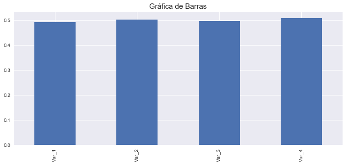

```python
Datos.mean().plot(kind='bar',title='Gráfica de Barras')
```

[output not shown]

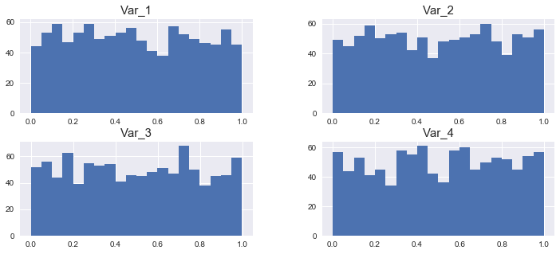

```python
Datos.hist(bins=20)
```

[output not shown]

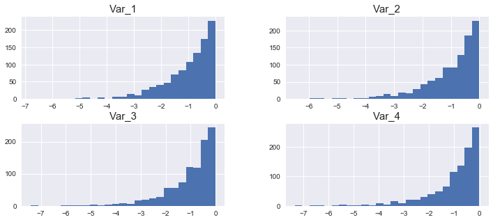

```python
#Histogramas con transformación de las variables mediante una función lambda

Datos.apply(lambda x: np.log(x)).hist(bins=25)
```

[output not shown]

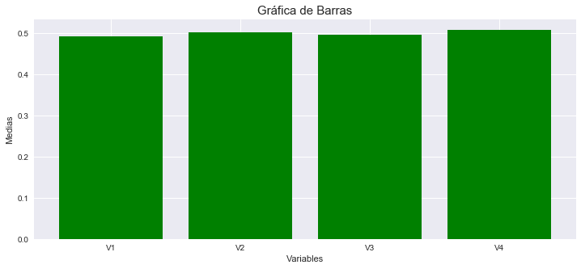

```python
Medias=Datos.mean()
filas=np.arange(4)
Nombres=Datos.columns.tolist()

plt.title('Gráfica de Barras')
plt.ylabel('Medias')
plt.xlabel('Variables')
plt.xticks(filas,('V1','V2','V3','V4'))
plt.bar(filas,Medias,color='green')
```

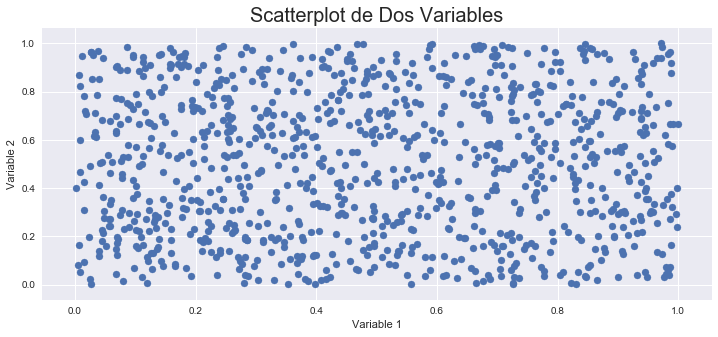

```python
#Relación entre variables{'fontsize': rcParams['axes.titlesize'],
plt.title("Scatterplot de Dos Variables",{'fontsize':20})
plt.ylabel('Variable 2')
plt.xlabel("Variable 1")
plt.scatter(Datos.Var_1,Datos.Var_2)
```

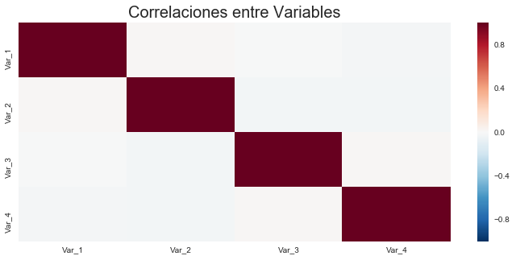

```python
#Gráficos con Seaborn

plt.title('Correlaciones entre Variables',{'fontsize':20})
sns.heatmap(Datos.corr())
```

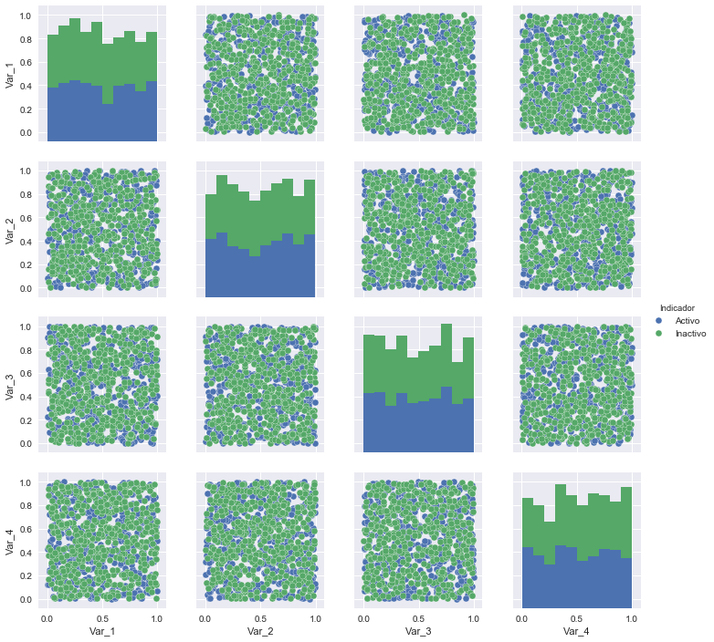

```python
#Se crea una variable para diferenciar los puntos que tienen menos de 0.5 y mayor o gual a0.5

#Se toman 500 indices aleatoreamente
arr=np.arange(0,1000)
np.random.shuffle(arr)

#Se crea una variable que se usará para crear 2 clases
Datos.loc[arr[:500],'Indicador']='Inactivo'
Datos.loc[arr[-500:],'Indicador']='Activo'

#Se grafican los Scatterplot de cada par y se muestra el comportamiento de los histogramas para cada clase
sns.pairplot(Datos,hue='Indicador')
```

En la industría o en las empresas, la parte visual de la exploración de los datos siempre está más relacionada con la ["Inteligencia de Negocios"](https://www.microsoft.com/es-es/sql-server/business-intelligence). Existen en el [mercado herramientas estándar](http://www.docurated.com/all-things-productivity/50-best-business-intelligence-tools), las desventajas de muchas de esas herramientas es la imposibilidad de hacer procesamiento de manejra flexible o rápida. Pero su ventaje es la facilidad para hacer gráficos de manera muy rápida y con un conocimiento mínimo.

Lo importante no siempre es solo la calidad de la visualización, sino la calidad de los datos visualizados y la intepretación que permitan hacer las exploraciones gráficas.

**Comentario:** Los módulos para hacer gráficos en Python se ha mejorado considerablemente en los recientes años. Al comparar la calidad de gráficos que se pueden crear en R versus lo de Python, ahora se cuenta con herramientas muy similares para casi todo tipo de visualización o gráfico.

Un ejemplo de como construir gráficos similares a los de R se ven en la siguiente liga:

- [Gráficos Similares a los de R](http://stackoverflow.com/questions/14349055/making-matplotlib-graphs-look-like-r-by-default)

## Otros Módulos y Opciones

Los módulos y herramientas para el desarrollo de software y sobre todo lo relacionado con computo científico o análisis de datos sigue evolucionando. En el tutorial solo consideramos algunos aspectos de nivel básico e intermedio.

Otros múdulos o lenguajes que pueden ser de interes son :

- [PyTables](http://www.pytables.org/)
- [PyMC3](http://pymc-devs.github.io/pymc3/)
- [AstroPy](http://www.astropy.org/)
- [stan](http://mc-stan.org/)
- [PySpark](https://spark.apache.org/docs/0.9.0/python-programming-guide.html)
- [theano](http://deeplearning.net/software/theano/)
- [keras](https://keras.io/)
- [tensorflow](https://www.tensorflow.org/)
- [Julia](https://julialang.org/)
- [Scala](https://www.scala-lang.org/)
- [Spark](https://spark.apache.org/)
- [R Project](https://www.r-project.org/)

Muchos de estos proyectos son soportados por [NumFOCUS](https://www.numfocus.org/) y otros por algunos laboratorios o empresas.

## Conclusiones

La intención de este Notebook es familiarizar brevemente con el entorno de módulos de Python para hacer análisis de Datos. Cada módulo puede contener aspectos que son sutiles y que requieren más horas de trabajo y práctica. En el tutorial se trata de explicar cada paso como cierto cuidado y en la medida de lo posible comentar o clarificar alguna operación que resulte extraña.

## Información del sistema

```python
#Detalles del sistema usado en este notebook
%load_ext version_information
%version_information scipy, numpy, matplotlib, seaborn, pandas
```

| Software | Version |
| --- | --- |
| Python | 3.6.0 64bit [GCC 4.4.7 20120313 (Red Hat 4.4.7-1)] |
| IPython | 6.1.0 |
| OS | Linux 4.4.0 79 generic x86_64 with debian jessie sid |
| scipy | 0.19.0 |
| numpy | 1.12.1 |
| matplotlib | 2.0.2 |
| seaborn | 0.7.1 |
| pandas | 0.20.2 |
| Sat Jun 10 16:02:33 2017 CDT |  |